# COMPSCIX 415.2 Homework 6

Gokila Rajaiah

March 12, 2018

```r
library(mosaicData)
library(tidyverse)
library(plyr)
```

#### Exercise 1.

###### 1.

Following are the 3 variables in Whickam dataset:

1. outcome
2. smoker
3. age

```r
glimpse(Whickham)
```

```
## Observations: 1,314
## Variables: 3
## $ outcome <fct> Alive, Alive, Dead, Alive, Alive, Alive, Alive, Dead, ...
## $ smoker  <fct> Yes, Yes, Yes, No, No, Yes, Yes, No, No, No, No, Yes, ...
## $ age     <int> 23, 18, 71, 67, 64, 38, 45, 76, 28, 27, 28, 34, 20, 72...
```

###### 2.

There are 1314 observations of a survey sample of Women classified as current smokers or having never smoked, age & their survival status after 20 years.

###### 3.

```r
#class(Whickham)
library(plyr)

smoker_outcome <- Whickham %>% count(c("smoker", "outcome"))

smoker_outcome
```

| smoker | outcome | freq |
| --- | --- | --- |
| No | Alive | 502 |
| No | Dead | 230 |
| Yes | Alive | 443 |
| Yes | Dead | 139 |

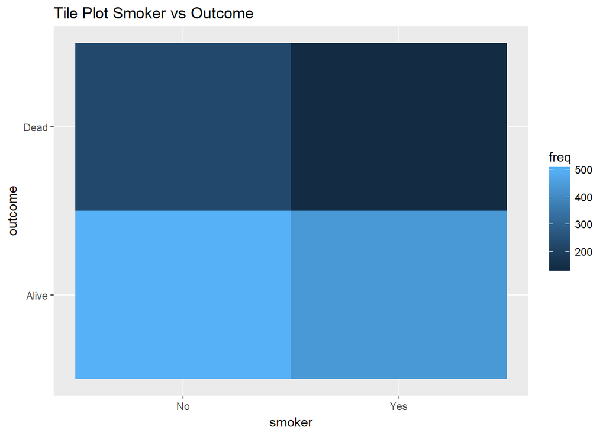

```r
ggplot(smoker_outcome, mapping = aes(x = smoker, y = outcome)) +
  geom_tile(mapping=aes(fill=freq)) +
  ggtitle("Tile Plot Smoker vs Outcome")
```

###### 4.

When the smoker’s death/alive rate is grouped by their age-group we can see that those who fall under age-group of 44 to 64 we see more number of people who smoke and their death rate is also high than death rate of those people who don’t smoke. People of age group less than 44 seem to have lesser death rate and it seems like smoking criteria doesn’t seem to affect that age group. Looking at the chart broken by age-group makes more sense as our theory matches with the data.

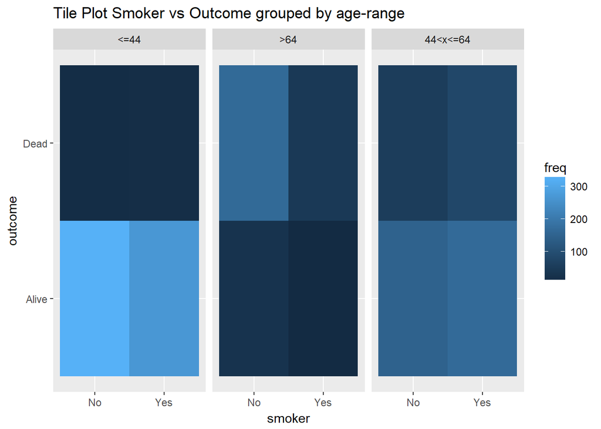

```r
out_table <- Whickham %>%
  mutate(age_range = case_when(age <= 44 ~ '<=44',
                               age > 44 & age <= 64 ~ '44<x<=64',
                               age > 64 ~ '>64')) %>%
  count(vars=c("outcome", "smoker", "age_range"))


  ggplot(out_table, mapping = aes(x = smoker, y = outcome)) +
    geom_tile(mapping=aes(fill=freq)) +
    facet_wrap(~ age_range) +
    ggtitle("Tile Plot Smoker vs Outcome grouped by age-range")
```

#### Exercise 2.

###### 1.

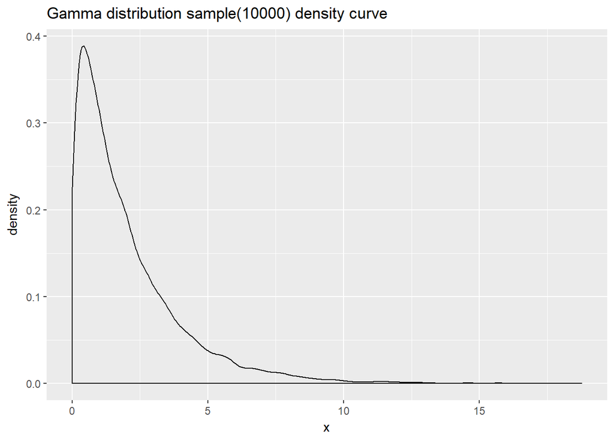

```r
n <- 10000

# Get a 10K sample of gamma distribution func.
gamma_samp <- tibble(x = rgamma(n, shape = 1, scale = 2))

#gamma_samp


ggplot(gamma_samp, aes(x=x)) + geom_density() +
ggtitle("Gamma distribution sample(10000) density curve")
```

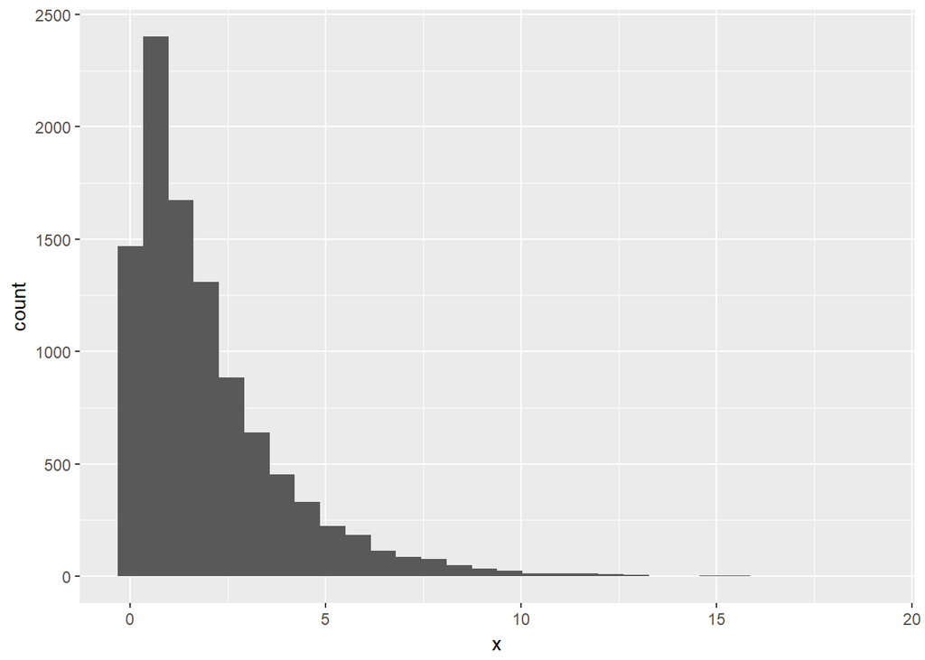

```r
ggplot(gamma_samp, mapping = aes(x)) + geom_histogram()
```

###### 2.

Yes. Both Mean & Standard Deviation are close to 2.0

```r
mean_samp <- gamma_samp %>% .[['x']] %>% mean()
sd_samp <- gamma_samp %>% .[['x']] %>% sd()

mean_samp
```

```
## [1] 1.97672
```

```r
sd_samp
```

```
## [1] 1.972441
```

###### 3.

Histogram, Density Curve, Mean & Standard deviation with a sample size of 30

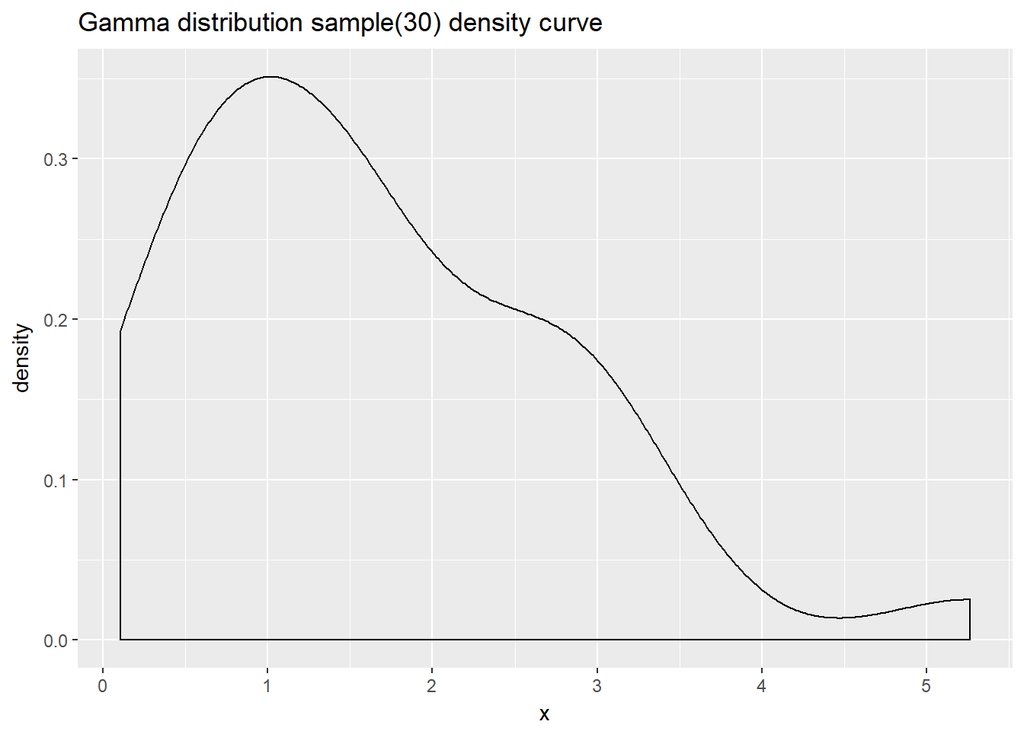

```r
n <- 30

# Get a 10K sample of gamma distribution func.
gamma_samp <- tibble(x = rgamma(n, shape = 1, scale = 2))

#gamma_samp


ggplot(gamma_samp, aes(x=x)) + geom_density() +
ggtitle("Gamma distribution sample(30) density curve")
```

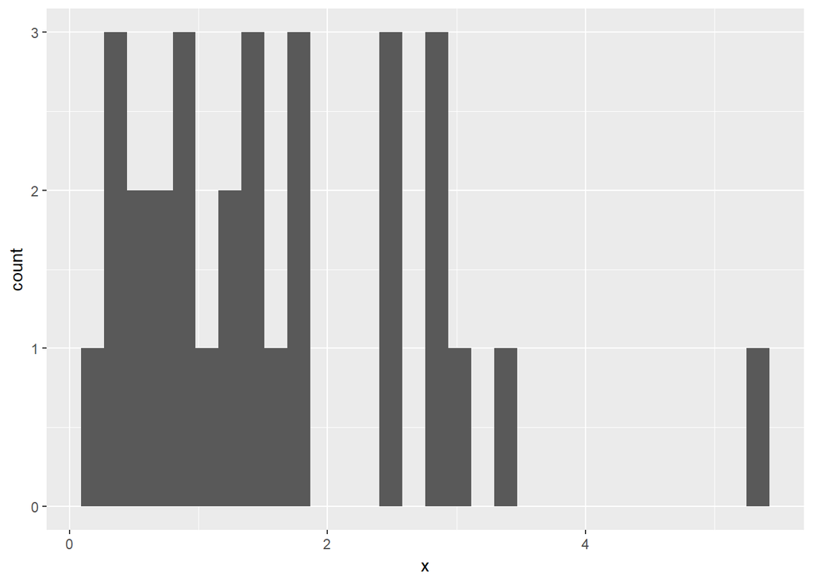

```r
ggplot(gamma_samp, mapping = aes(x)) + geom_histogram()
```

```r
(mean_samp <- gamma_samp %>% .[['x']] %>% mean())
```

```
## [1] 1.643877
```

```r
(sd_samp <- gamma_samp %>% .[['x']] %>% sd())
```

```
## [1] 1.166199
```

###### 4.

Taking Mean & SD of 30 samples 10K times

```r
# create a vector with 10000 NAs
mean_samp <- rep(NA, 10000)

# start a loop
for(i in 1:10000) {
  g_samp <- tibble(x = rgamma(30, shape = 1, scale = 2))

  mean_samp[i] <- g_samp %>% .[['x']] %>% mean()
}
# Convert vector to a tibble
(mean_samp_t <- tibble(mean_samp))
```

| mean_samp |
| --- |
| 1.7698804 |
| 1.9040031 |
| 2.1100999 |
| 2.0910005 |
| 2.0315932 |
| 2.3308824 |
| 2.1381248 |
| 1.6089578 |
| 2.1148568 |
| 2.0589267 |

[output cut: 9990 more lines]

###### 5.

Histogram of 10K Sample Means:

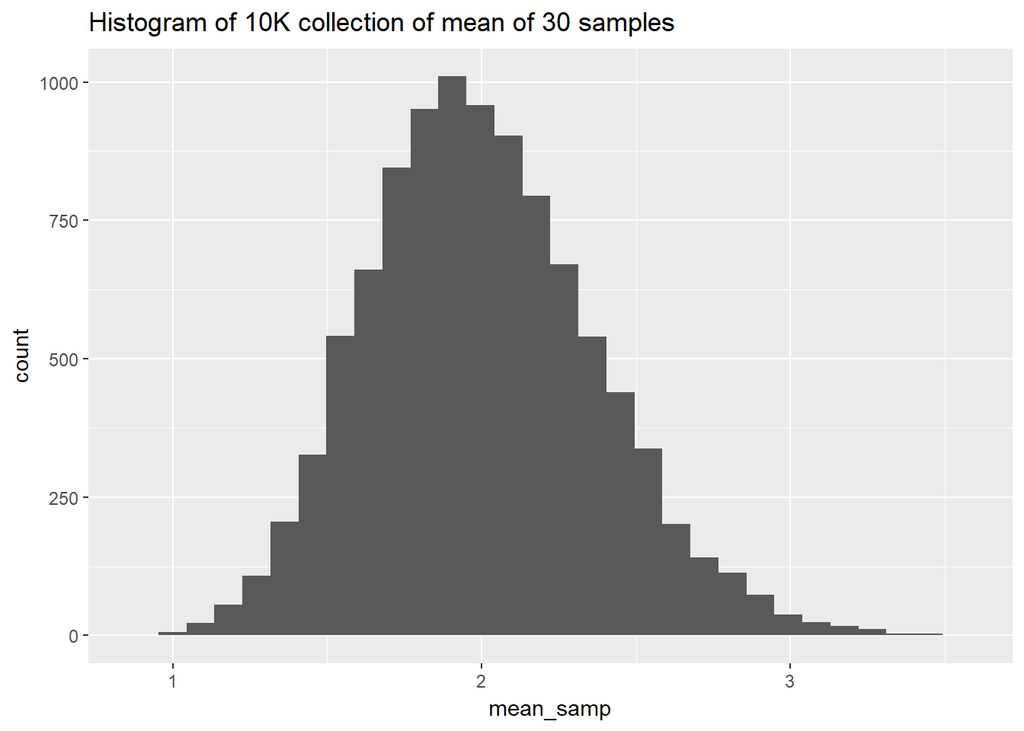

```r
ggplot(mean_samp_t, mapping = aes(mean_samp)) +
  geom_histogram() +
  ggtitle("Histogram of 10K collection of mean of 30 samples")
```

###### 6.

Mean & SD of sample means

```r
mean_mean_samp_t <- mean_samp_t %>% .[['mean_samp']] %>% mean()
sd_mean_samp_t <- mean_samp_t %>% .[['mean_samp']] %>% sd()

mean_mean_samp_t
```

```
## [1] 2.001184
```

```r
sd_mean_samp_t
```

```
## [1] 0.3672203
```

###### 7.

Mean of sample means is close to 2.0, which is expected. But Standard Deviation of all the mean samples is so different (0.36) from the standard devitaion of one sample (2.0)

###### 8.

Yes. Mean & Standard Deviation of a sample means using sample size 300 is matching up with the central limit theroem. Mean is close to 2 and Standard deviation is
$$\frac{\alpha}{\sqrt{n}} = \frac{2}{\sqrt{300}} = 0.11$$

```r
sample_size = 300
repeat_times = 10000

# create a vector with 10000 NAs
mean_samp <- rep(NA, repeat_times)

# start a loop
for(i in 1:repeat_times) {
  g_samp <- tibble(x = rgamma(sample_size, shape = 1, scale = 2))

  mean_samp[i] <- g_samp %>% .[['x']] %>% mean()
}
# Convert vector to a tibble
mean_samp_t <- tibble(mean_samp)
mean_samp_t
```

| mean_samp |
| --- |
| 2.041225 |
| 1.679536 |
| 2.034505 |
| 1.938802 |
| 1.909866 |
| 1.997956 |
| 2.118230 |
| 1.824584 |
| 1.932627 |
| 1.908735 |

[output cut: 9990 more lines]

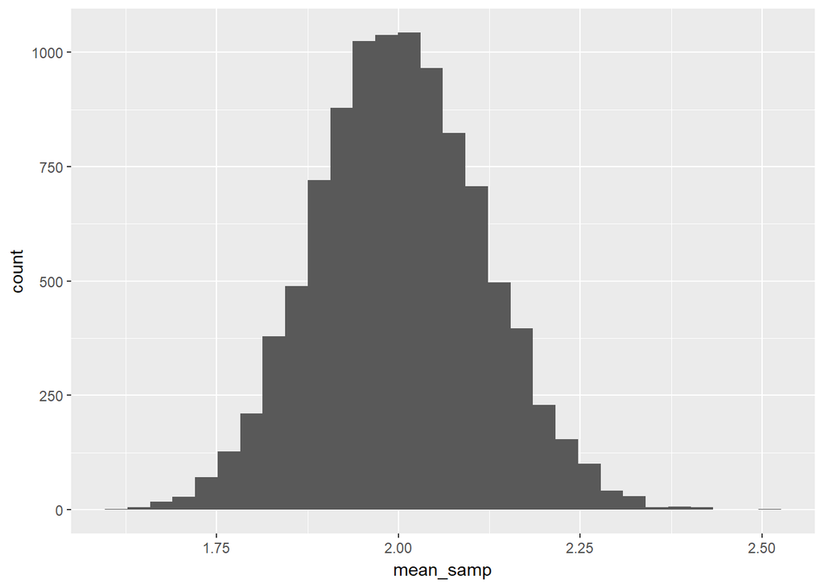

```r
ggplot(mean_samp_t, mapping = aes(mean_samp)) +
  geom_histogram()
```

```r
(mean_mean_samp_t <- mean_samp_t %>% .[['mean_samp']] %>% mean())
```

```
## [1] 2.001759
```

```r
(sd_mean_samp_t <- mean_samp_t %>% .[['mean_samp']] %>% sd())
```

```
## [1] 0.1152031
```